# Experimental Design and Probability

## Linear models as a unifying framework

We will learn the essentials

```
- t-tests
- regression
- analysis of variance
```

in the context of linear models:

\[ y = \alpha + \beta x \]

### What is a model?

## Models

Model: a mathematical representation of the relationship between a response variable \(y\) and one or more explanatory variables.

All models are wrong, but some are useful (George Box)

## Linear models

A model is *linear* if \(y\) can be written as a linear function of the *parameters* (e.g., \(\beta\)).

## Linear models

Linear

\[ \begin{aligned} y = \alpha + \beta x \\ y = \alpha + \beta_1 x + \beta_2 x^2 \\ \end{aligned} \]

Non-linear

\[ \begin{aligned} y = \alpha x^ \beta \\ y = \alpha \beta ^x \\ y = \frac{\beta_1x}{\beta_2 + x} \end{aligned} \]

## Linear models

General equation for a linear model:

\[ \begin{aligned} y_i = \alpha + \sum{\beta_ix_i} + \epsilon_i \\ \epsilon_i \sim N(0, \sigma) \end{aligned} \]

## Example: linear regression

Does higher plant biodiversity affect ecosystem stability?

Tilman et al. (2006) seeded 161 plots (9 x 9m) with varying numbers of plant species (1, 2, 4, 8, 16).

Plant species were assigned randomly to plots (18 possible species).

After 10 years of maintenance and measurement, researchers measured the *stability* of plant biomass production for each plot:

\[ \begin{aligned} \text{Biomass stability} = \frac{\bar{x}_\text{biomass}}{s_\text{biomass over 10 years}} \\ \end{aligned} \]

## Load the data

```r
# Packages
library(tidyverse)
library(broom)
theme_set(theme_bw(base_size = 14) +
            theme(panel.grid = element_blank()))

# Set the web address where R will look for files from this repository
repo_url <- "https://raw.githubusercontent.com/elahi/xdp/master/data/"
dat <- read_csv(paste(repo_url,
                      "chap17e3PlantDiversityAndStabilityRaw.csv",
                      sep = ""))
dat <- dat %>%
  mutate(stability_log = log(biomassStability)) # natural log (base e)
```

Simple linear regression model

\[ \begin{aligned} \text{log(stability)} = \alpha + \beta (\text{species number}) + \epsilon \\ \end{aligned} \]

```r
m1 <- lm(stability_log ~ nSpecies, data = dat)
tidy(m1)
```

```
## # A tibble: 2 x 5
##   term        estimate std.error statistic  p.value
##   <chr>          <dbl>     <dbl>     <dbl>    <dbl>
## 1 (Intercept)    3.41     0.205      16.6  1.37e-36
## 2 nSpecies       0.160    0.0243      6.62 5.32e-10
```

**Write the linear model with model coefficients**

Null model

\[ \begin{aligned} \text{log(stability)} = \alpha + \epsilon \\ \end{aligned} \]

```r
m0 <- lm(stability_log ~ 1, data = dat)
tidy(m0)
```

```
## # A tibble: 1 x 5
##   term        estimate std.error statistic  p.value
##   <chr>          <dbl>     <dbl>     <dbl>    <dbl>
## 1 (Intercept)     4.42     0.154      28.8 3.34e-65
```

```r
mean(dat$stability_log)
```

```
## [1] 4.421801
```

**Write the linear model with model coefficients**

## Visualizing null vs regression model

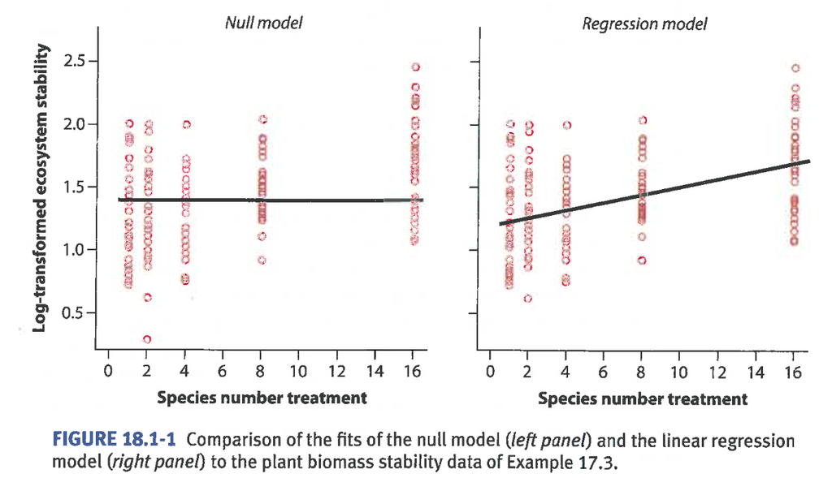

## ANOVA tables for lm()

```r
anova(m0)
```

```
## Analysis of Variance Table
##
## Response: stability_log
##            Df Sum Sq Mean Sq F value Pr(>F)
## Residuals 160 606.99  3.7937
```

```r
anova(m1)
```

```
## Analysis of Variance Table
##
## Response: stability_log
##            Df Sum Sq Mean Sq F value    Pr(>F)
## nSpecies    1 131.06 131.061  43.785 5.318e-10 ***
## Residuals 159 475.93   2.993
## ---
## Signif. codes:  0 '***' 0.001 '**' 0.01 '*' 0.05 '.' 0.1 ' ' 1
```

## Comparing linear models

```r
anova(m0, m1)
```

```
## Analysis of Variance Table
##
## Model 1: stability_log ~ 1
## Model 2: stability_log ~ nSpecies
##   Res.Df    RSS Df Sum of Sq      F    Pr(>F)
## 1    160 606.99
## 2    159 475.93  1    131.06 43.785 5.318e-10 ***
## ---
## Signif. codes:  0 '***' 0.001 '**' 0.01 '*' 0.05 '.' 0.1 ' ' 1
```

## T-tests as linear models

- one-sample t-test
- paired t-test
- two-sample t-test

## One-sample t-test as a linear model

One number (intercept, i.e., the mean), predicts \(y\)

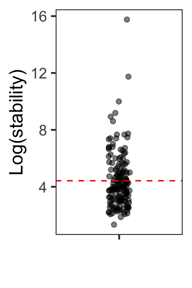

```r
t.test(x = dat$stability_log)
summary(lm(stability_log ~ 1, data = dat))
```

## One-sample t-test as a linear model

```
##
##  One Sample t-test
##
## data:  dat$stability_log
## t = 28.806, df = 160, p-value < 2.2e-16
## alternative hypothesis: true mean is not equal to 0
## 95 percent confidence interval:
##  4.118648 4.724955
## sample estimates:
## mean of x
##  4.421801
```

```
##
## Call:
## lm(formula = stability_log ~ 1, data = dat)
##
## Residuals:
##     Min      1Q  Median      3Q     Max
## -3.0818 -1.3518 -0.4218  0.7782 11.3382
##
## Coefficients:
##             Estimate Std. Error t value Pr(>|t|)
## (Intercept)   4.4218     0.1535   28.81   <2e-16 ***
## ---
## Signif. codes:  0 '***' 0.001 '**' 0.01 '*' 0.05 '.' 0.1 ' ' 1
##
## Residual standard error: 1.948 on 160 degrees of freedom
```

## Paired t-test as a linear model

One intercept predicts the pairwise \(y_2 - y_1\) differences

```r
## Example code; does not run
t.test(x = y2, y = y1, paired = TRUE)
summary(lm(y2 - y1 ~ 1, data = dat))
```

## Two-sample t-test as a linear model

An intercept for *group 1* (plus a difference if *group 2*) predicts \(y\)

```r
## Example code; does not run
t.test(x = y2, y = y1, var.equal = TRUE)
summary(lm(y1 ~ 1 + group2, data = dat)) # ANOVA w/ two groups
```

Linear model for analysis of variance:

\[ \begin{aligned} y_{ij} = \mu + A_i + \epsilon_{ij} \\ \end{aligned} \]

In this case, factor A has two groups.

## ANOVA as linear model: example

```r
dat <- read_csv(paste(repo_url, "chap15e1KneesWhoSayNight.csv",
                      sep = ""))
```

\[ \begin{aligned} \text{shift}_{ij} = \mu + \text{treatment}_i + \epsilon_{ij} \\ \end{aligned} \]

```r
m0 <- lm(shift ~ 1, data = dat) # null model
m1 <- lm(shift ~ treatment, data = dat)
```

```r
tidy(m0)
```

```
## # A tibble: 1 x 5
##   term        estimate std.error statistic p.value
##   <chr>          <dbl>     <dbl>     <dbl>   <dbl>
## 1 (Intercept)   -0.713     0.190     -3.76 0.00116
```

```r
tidy(m1)
```

```
## # A tibble: 3 x 5
##   term          estimate std.error statistic p.value
##   <chr>            <dbl>     <dbl>     <dbl>   <dbl>
## 1 (Intercept)    -0.309      0.249   -1.24   0.230
## 2 treatmenteyes  -1.24       0.364   -3.41   0.00293
## 3 treatmentknee  -0.0270     0.364   -0.0740 0.942
```

**Write the linear models with model coefficients**

## Visualizing null vs ANOVA model

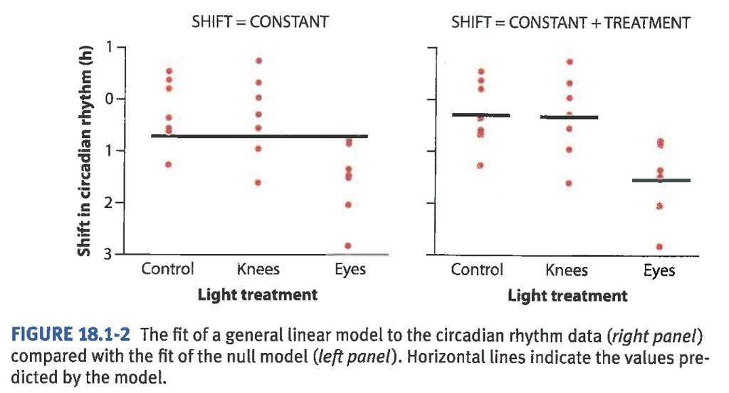

## ANOVA as linear model: results

```r
anova(m1)
```

```
## Analysis of Variance Table
##
## Response: shift
##           Df Sum Sq Mean Sq F value   Pr(>F)
## treatment  2 7.2245  3.6122  7.2894 0.004472 **
## Residuals 19 9.4153  0.4955
## ---
## Signif. codes:  0 '***' 0.001 '**' 0.01 '*' 0.05 '.' 0.1 ' ' 1
```

```r
anova(m0, m1)
```

```
## Analysis of Variance Table
##
## Model 1: shift ~ 1
## Model 2: shift ~ treatment
##   Res.Df     RSS Df Sum of Sq      F   Pr(>F)
## 1     21 16.6398
## 2     19  9.4153  2    7.2245 7.2894 0.004472 **
## ---
## Signif. codes:  0 '***' 0.001 '**' 0.01 '*' 0.05 '.' 0.1 ' ' 1
```

## Exercises

### **Use the following data to conduct a t-test:**

```r
cleared <- c(3.012, 1.021, 3.240, 3.613, 1.650, 4.090, 2.980)
control <- c(2.416, 0.980, 2.098, 2.346, 1.057, 2.910, 2.063)
dat <- data.frame(day = seq(1, 7, by = 1), cleared, control)
dat_long <- dat %>% gather(key = treatment, value = par, cleared:control)
t.test(par ~ treatment, data = dat_long, var.equal = TRUE)
```

Now use a lm() on the same data. Compare the outputs from the two analyses. Write the linear model with coefficients.

### **Whitlock and Schluter, Chapter 18, #2 (p 626)**

## References

Whitlock and Schluter, 2015. Analysis of Biological Data.

https://lindeloev.github.io/tests-as-linear/